# **Problem Statement**

#### **Question 11**: Perform cluster profiling on the data using a barplot for the K-Means algorithm. Provide insights and key observations for each cluster based on the visual analysis.

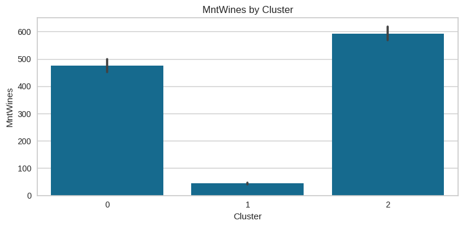

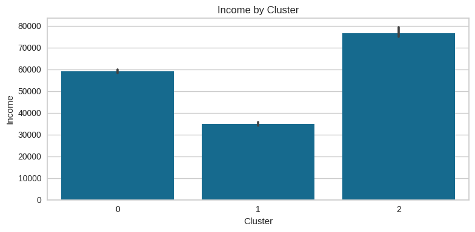

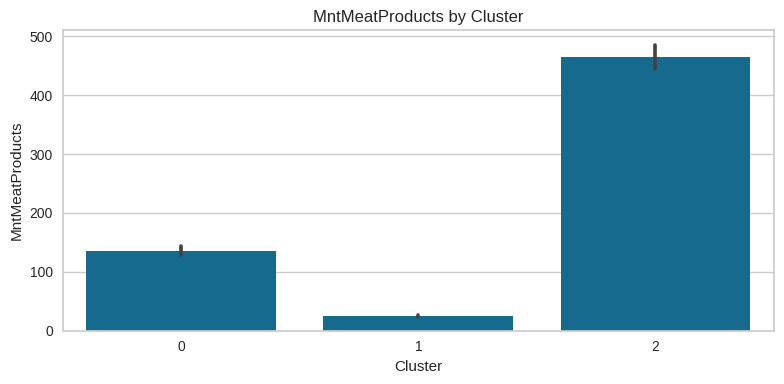

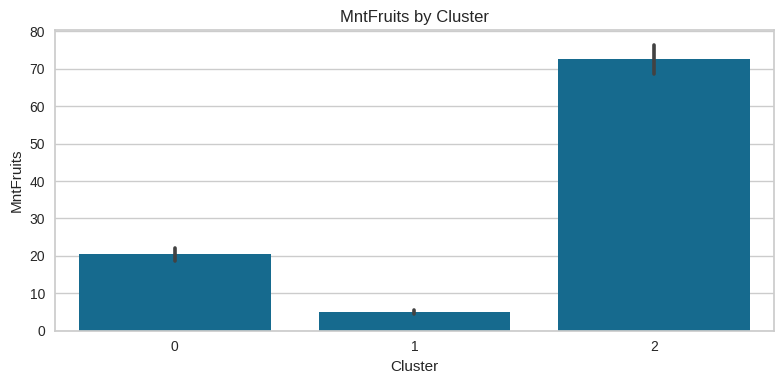

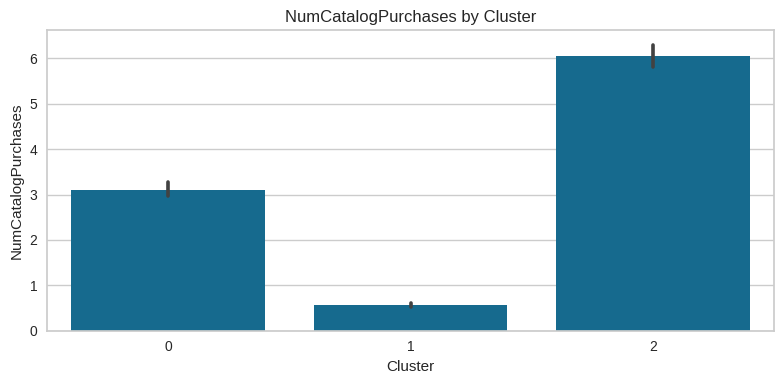

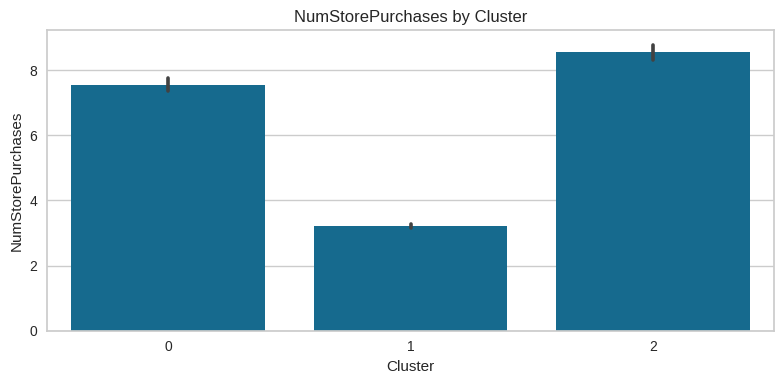

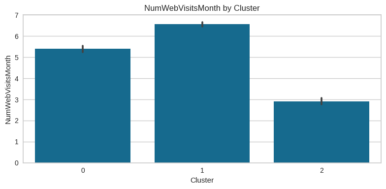

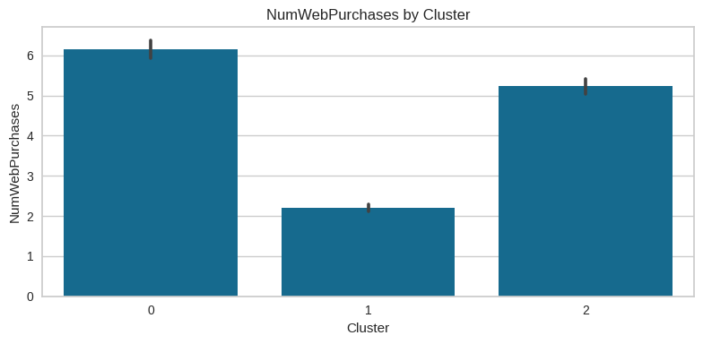

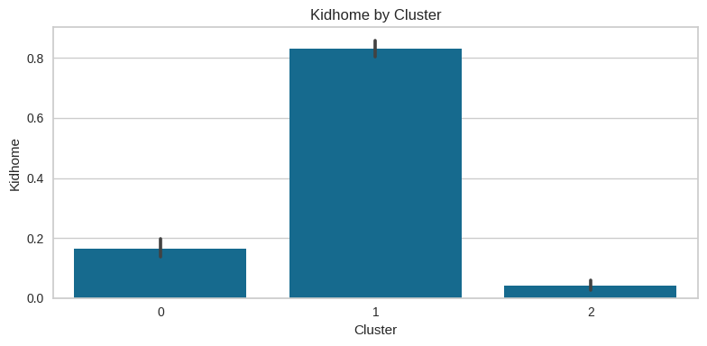

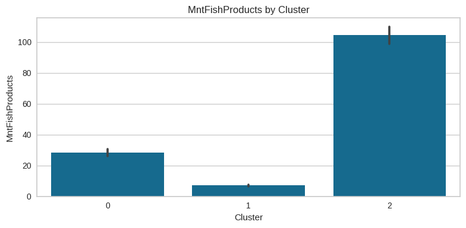

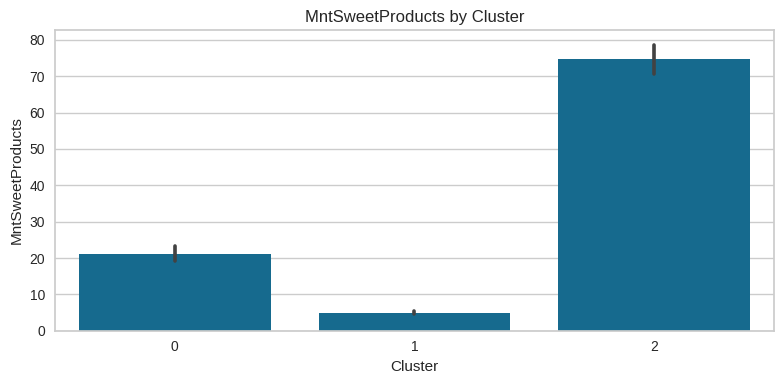

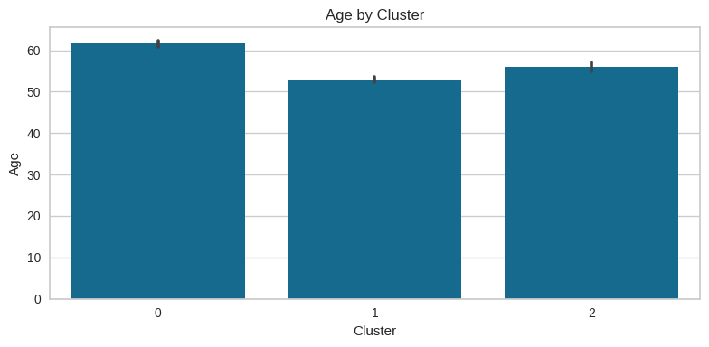

```python
# Creating barplots for each column
for col in features:
    plt.figure(figsize=(8, 4))
    sns.barplot(x='Cluster', y=col, data=correlated_variables)
    plt.title(f'{col} by Cluster')
    plt.xlabel('Cluster')
    plt.ylabel(col)
    plt.tight_layout()
    plt.show()
```

## **Business Recommedations**

#### **Question 12**: Based on the cluster insights, what business recommendations can be provided?

Based on the clusters and objectives of the project, I would make the following recommendations:

*Objective 1: Develop personalized marketing campaigns to increase conversion rates*

**Recommendation 1:** Cluster 1 (the lower income group) tends to have the highest web visits but lowest web purchases. As mentioned previously, this may indicate that the group is shopping for the best/lowest deals, then finding it elsewhere and not converting to a sale for our company. This may be a group to target marketing in that you can advertize to them with a discount for online purchasing, or even advertize online for in-store sales to motivate them to come into the store to purchase items.

*Objective 2: Create effective retention strategies for high-value customers*

**Recommendation 2:** Cluster 2 contains the high-value customers, meaning they tend to spend the most on products across the board and are most loyal to the company. Even though they are high loyalty customers, you want to ensure that you are retaining these customers for the long-term. To do this, I would recommend implementing a loyalty or rewards program offering them discounts or money back after spending a certain dollar amount. Another option could be offering birthday rewards for these customers giving them money off during their birthday month or even targetting their product preferences with free or discounted bottle of wine or sweet item (slice of cake) for their birthday. Additionally you could implement exclusive benefits for being a loyalty member including sales that are specifically targetting this group or early access to an upcoming sale.

**Recommendation 3:** Cluster 0 has the highest web purchases of all three clusters. Interestingly, the number of web purchases is higher than number of web visits. I would think that in order to purchase, you have to visit the website, so I would expect visits to be higher than purchases. However, potentially customers make a purchase, then return to the site to purchase additional items they forgot to order, or maybe they purchase multiple times in a week/month and those are counted only as one web visit. I would want to clarify this. Whatever the reason, this cluster seems more consistent with web purchases/visits, so targeting them for online promotions or rewards might be beneficial to retain them as the online customer base.

*Objective 3: Optimize resource allocation, such as inventory management, pricing strategies, and store layouts*

**Recommendation 4:** Clusters 0 and 2 tend to spend the most on wine and meat. These groups also have higher number of in-store purchases. When considering store layout, it may make sense to place wine near the meats to encourage customers to purchase the two items together.

**Recommendation 5:** As discussed previously, the total amount spent on items from highest to lowest was for wine, meat, fish, and lastly fruit/sweets are fairly similar. Knowing this can help the company estimate what type and how much inventory to stock in our store or warehouses. However, this is somewhat misleading because fruits and sweets are typically cheaper to buy compared to meat, fish, and wine, so customers may be spending a higher dollar amount on higher priced items, they may be purchasing larger volume of the lower priced items. For example, a customer purchases a 30 dollar bottle of wine but may need to purchase 6 items in the sweets category to amount to 30 dollars. Even so, this does give us a general idea of how to stock products.

**Recommendation 6:** Cluster 1 appears to be our least loyal customer group, but may have the most potential for increased sales. I might recommend offering them discounts for the first 90 days of their membership to increase likelihood of them purchasing from our store, with the hope that they will enjoy our product offerings and continue converting to sales once the discount period is over.